# DS08 - Prediction Assignment Writeup

Nicola Bronzino

Tuesday, November 10, 2015

# Background

It is now possible to collect a large amount of data about personal activity relatively inexpensively.  
In this project, our goal is to use data from accelerometers on the belt, forearm, arm, and dumbell of 6 participants.  
They were asked to perform barbell lifts correctly and incorrectly in 5 different ways.  
The goal of the project is to predict the manner in which they did the exercise. This is the “classe” variable in the training set.

# Data Load

Data are downloaded from the links where they’re available (one for training data, one for testing data) and loaded into correspondent data frames.

```r
set.seed(13234)

trainUrl <- "http://d396qusza40orc.cloudfront.net/predmachlearn/pml-training.csv"
testUrl <- "http://d396qusza40orc.cloudfront.net/predmachlearn/pml-testing.csv"

training <- read.csv(trainUrl)
testing <- read.csv(testUrl)

#showing number of rows and columns of the two datasets
dim(training)
```

```
## [1] 19622   160
```

```r
dim(testing)
```

```
## [1]  20 160
```

Due to the limited number of observations in the testing data set, we partition training data set.

```r
inTrain <- createDataPartition(training$classe,p=0.7,list=FALSE)
newTrain <- training[inTrain,]
newTest  <- training[-inTrain,]

dim(newTrain)
```

```
## [1] 13737   160
```

```r
dim(newTest)
```

```
## [1] 5885  160
```

# Preprocessing

```r
#01. removing variables with more than 60% of NAs
threshold <- 0.6
col_to_select <- c()

for (i in 1:ncol(newTrain)) {
    curcol <- newTrain[,i]
    colind <- sum(is.na(curcol))/length(curcol)
    if (colind <= threshold) {
        col_to_select <- c(col_to_select,i)
    }

}

#02. removing columns X and user_name
X_position <- which(names(newTrain)=="X")
user_position <- which(names(newTrain)=="user_name")
ts1_position <- which(names(newTrain)=="raw_timestamp_part_1")
ts2_position <- which(names(newTrain)=="raw_timestamp_part_2")
ts3_position <- which(names(newTrain)=="cvtd_timestamp")
window_position <- which(names(newTrain)=="num_window")

col_to_select <- col_to_select[-c(X_position,user_position,ts1_position,ts2_position,ts3_position,window_position)]

newTrain <- newTrain[,col_to_select]
newTest  <- newTest[,col_to_select]

#03. removing variables with no variance
nzvTrain <- nearZeroVar(newTrain, saveMetrics=TRUE)
nzvTest  <- nearZeroVar(newTest,  saveMetrics=TRUE)

newTrain <- newTrain[,nzvTrain$nzv==FALSE]
newTest  <- newTest[,nzvTest$nzv==FALSE]

dim(newTrain)
```

```
## [1] 13737    53
```

```r
dim(newTest)
```

```
## [1] 5885   53
```

# Creation of the Model

In order to evaluate different approaches to prediction model, different models will be built.  
1. Decision Tree  
2. Random Forest  
3. Generalized Boosted Regression  
All the models are created considering as predictors all the variables except classe (the outcome).

```r
#01. Decision Tree
modFit01 <- train(classe ~ .,data=newTrain,method="rpart",trControl = trainControl(method = "cv", number = 3))
modFit01$finalModel
```

```
## n= 13737
##
## node), split, n, loss, yval, (yprob)
##       * denotes terminal node
##
##  1) root 13737 9800 A (0.28 0.19 0.17 0.16 0.18)
##    2) roll_belt< 1.3e+02 12578 8700 A (0.31 0.21 0.19 0.18 0.11)
##      4) pitch_forearm< -34 1104    7 A (0.99 0.0063 0 0 0) *
##      5) pitch_forearm>=-34 11474 8700 A (0.24 0.23 0.21 0.2 0.12)
##       10) magnet_dumbbell_y< 4.4e+02 9716 7000 A (0.28 0.18 0.24 0.19 0.11)
##         20) roll_forearm< 1.2e+02 6067 3600 A (0.4 0.18 0.19 0.16 0.059) *
##         21) roll_forearm>=1.2e+02 3649 2500 C (0.082 0.18 0.32 0.23 0.18) *
##       11) magnet_dumbbell_y>=4.4e+02 1758  880 B (0.03 0.5 0.04 0.23 0.2) *
##    3) roll_belt>=1.3e+02 1159   12 E (0.01 0 0 0 0.99) *
```

```r
#02. Random Forest
modFit02 <- train(classe ~ .,data=newTrain,method="rf",prox=TRUE,trControl = trainControl(method = "cv", number = 3))
modFit02$finalModel
```

```
##
## Call:
##  randomForest(x = x, y = y, mtry = param$mtry, proximity = TRUE)
##                Type of random forest: classification
##                      Number of trees: 500
## No. of variables tried at each split: 27
##
##         OOB estimate of  error rate: 0.66%
## Confusion matrix:
##      A    B    C    D    E class.error
## A 3902    3    1    0    0      0.0010
## B   20 2630    8    0    0      0.0105
## C    0   13 2373   10    0      0.0096
## D    0    1   23 2227    1      0.0111
## E    0    0    6    5 2514      0.0044
```

```r
#03. Generalized Boosted Regression
modFit03 <- train(classe ~ .,data=newTrain,method="gbm",verbose=FALSE, trControl = trainControl(method = "cv", number = 3))
modFit03$finalModel
```

```
## A gradient boosted model with multinomial loss function.
## 150 iterations were performed.
## There were 52 predictors of which 40 had non-zero influence.
```

# Prediction

Models generated in the previous point are applied to newTest dataset.

```r
#01. Decision Tree
pred01 <- predict(modFit01,newTest)
CM01 <- confusionMatrix(pred01,newTest$classe)
CM01
```

```
## Confusion Matrix and Statistics
##
##           Reference
## Prediction    A    B    C    D    E
##          A 1537  457  440  449  167
##          B   28  408   38  159  138
##          C  107  274  548  356  293
##          D    0    0    0    0    0
##          E    2    0    0    0  484
##
## Overall Statistics
##
##                Accuracy : 0.506
##                  95% CI : (0.493, 0.519)
##     No Information Rate : 0.284
##     P-Value [Acc > NIR] : <2e-16
##
##                   Kappa : 0.354
##  Mcnemar's Test P-Value : NA
##
## Statistics by Class:
##
##                      Class: A Class: B Class: C Class: D Class: E
## Sensitivity             0.918   0.3582   0.5341    0.000   0.4473
## Specificity             0.641   0.9235   0.7880    1.000   0.9996
## Pos Pred Value          0.504   0.5292   0.3473      NaN   0.9959
## Neg Pred Value          0.952   0.8571   0.8890    0.836   0.8892
## Prevalence              0.284   0.1935   0.1743    0.164   0.1839
## Detection Rate          0.261   0.0693   0.0931    0.000   0.0822
## Detection Prevalence    0.518   0.1310   0.2681    0.000   0.0826
## Balanced Accuracy       0.779   0.6409   0.6611    0.500   0.7235
```

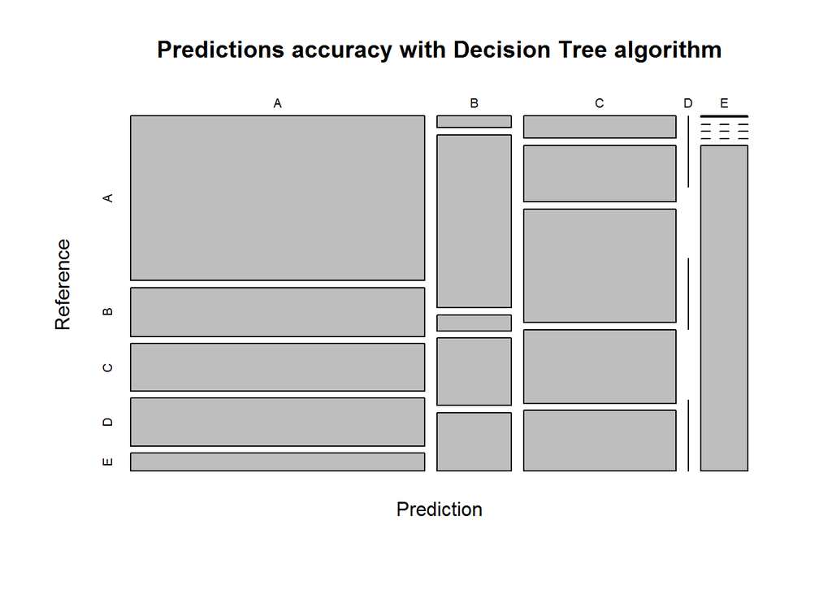

```r
plot(CM01$table,main="Predictions accuracy with Decision Tree algorithm")
```

```r
#02. Random Forest
pred02 <- predict(modFit02,newdata=newTest)
CM02 <- confusionMatrix(pred02,newTest$classe)
CM02
```

```
## Confusion Matrix and Statistics
##
##           Reference
## Prediction    A    B    C    D    E
##          A 1673    4    0    0    0
##          B    0 1130    3    0    1
##          C    0    5 1017    9    4
##          D    0    0    6  953    0
##          E    1    0    0    2 1077
##
## Overall Statistics
##
##                Accuracy : 0.994
##                  95% CI : (0.992, 0.996)
##     No Information Rate : 0.284
##     P-Value [Acc > NIR] : <2e-16
##
##                   Kappa : 0.992
##  Mcnemar's Test P-Value : NA
##
## Statistics by Class:
##
##                      Class: A Class: B Class: C Class: D Class: E
## Sensitivity             0.999    0.992    0.991    0.989    0.995
## Specificity             0.999    0.999    0.996    0.999    0.999
## Pos Pred Value          0.998    0.996    0.983    0.994    0.997
## Neg Pred Value          1.000    0.998    0.998    0.998    0.999
## Prevalence              0.284    0.194    0.174    0.164    0.184
## Detection Rate          0.284    0.192    0.173    0.162    0.183
## Detection Prevalence    0.285    0.193    0.176    0.163    0.184
## Balanced Accuracy       0.999    0.996    0.994    0.994    0.997
```

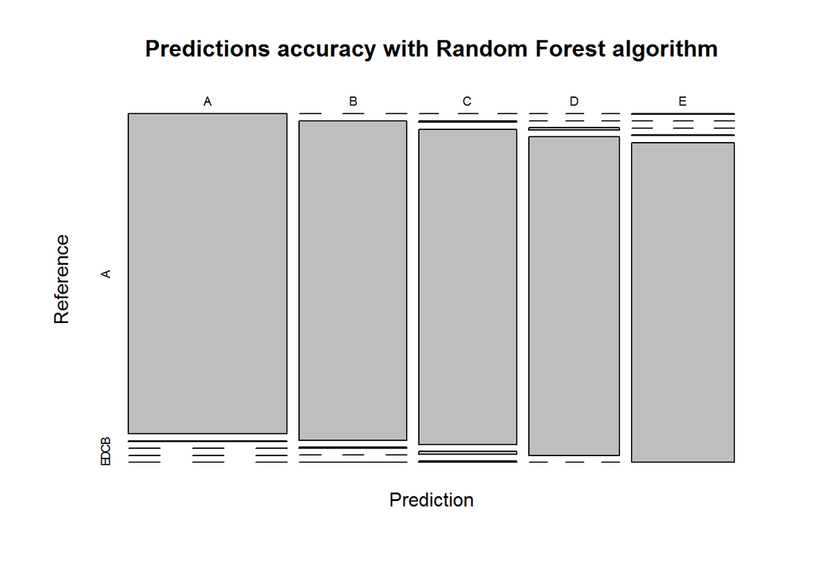

```r
plot(CM02$table,main="Predictions accuracy with Random Forest algorithm")
```

```r
#03. Generalized Boosted Regression
pred03 <- predict(modFit03,newdata=newTest)
CM03 <- confusionMatrix(pred03,newTest$classe)
CM03
```

```
## Confusion Matrix and Statistics
##
##           Reference
## Prediction    A    B    C    D    E
##          A 1644   30    0    0    1
##          B   17 1076   40    3   13
##          C    4   28  969   30    9
##          D    8    2   16  922   13
##          E    1    3    1    9 1046
##
## Overall Statistics
##
##                Accuracy : 0.961
##                  95% CI : (0.956, 0.966)
##     No Information Rate : 0.284
##     P-Value [Acc > NIR] : <2e-16
##
##                   Kappa : 0.951
##  Mcnemar's Test P-Value : 0.0001
##
## Statistics by Class:
##
##                      Class: A Class: B Class: C Class: D Class: E
## Sensitivity             0.982    0.945    0.944    0.956    0.967
## Specificity             0.993    0.985    0.985    0.992    0.997
## Pos Pred Value          0.981    0.936    0.932    0.959    0.987
## Neg Pred Value          0.993    0.987    0.988    0.991    0.993
## Prevalence              0.284    0.194    0.174    0.164    0.184
## Detection Rate          0.279    0.183    0.165    0.157    0.178
## Detection Prevalence    0.285    0.195    0.177    0.163    0.180
## Balanced Accuracy       0.987    0.965    0.965    0.974    0.982
```

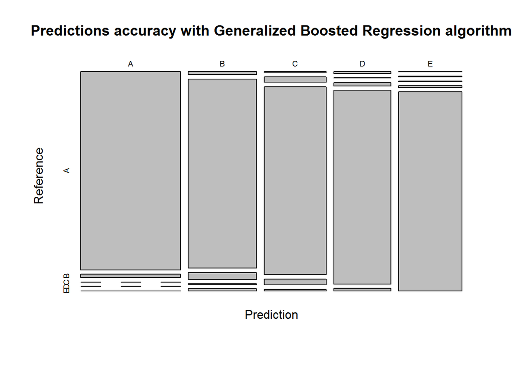

```r
plot(CM03$table,main="Predictions accuracy with Generalized Boosted Regression algorithm")
```

# Conclusion

```r
#calculation of accuracies
acc01 <- CM01[[3]][[1]]*100
acc02 <- CM02[[3]][[1]]*100
acc03 <- CM03[[3]][[1]]*100

accuracies <- data.frame(rbind(acc01,acc02,acc03))
names(accuracies) <- c("value")
accuracies$model <- c("Decision Tree","Random Forest","Generalized Boosted Regression")

accuracies <- accuracies[order(accuracies$value,decreasing=TRUE),]

maxacc <- accuracies[1,1]
bestmodel <- accuracies[1,2]

predErr <- 100 - maxacc
```

Based on accuracy in prediction, model with best performance in prediction is **Random Forest**, that has an accuracy of **99.41**%.  
Error is equal to **0.59**%.

# Test set

Selected model is applied to the test data set and file with answers for the submission is generated.

```r
predTest <- predict(modFit02,newdata=testing)
write.csv(predTest,"testing_result.csv")
```